# Biomass and Resin Data Characterization

# Key Questions:

Biomass:

- What is the rationale / timing behind biomass data collection? Does variation in sampling date correspond to interannual differences in precip or phenology?
- Is there a way to chunk up measures of biomass or standardize them to make comparison easier?

Resins:

- Best way to analyze data - net NH4 / NO3 captured per day of incubation in soil.
- What to do about data that is not blank-corrected?

Compiled on Fri Aug 17 12:25:36 2018

# Loading packages

```r
library(tidyverse);library(ggplot2);library(lubridate)
```

# Reading in data

```r
# Biomass Data
bmdat <- read.csv("../data/biomass_all.csv", stringsAsFactors = FALSE)
head(bmdat)
```

|  | Date | Plot | SortedLive | SortedLitter | TotalMass | LiveMass | LitterMass | Masspermeter |
| --- | --- | --- | --- | --- | --- | --- | --- | --- |
| 1 | 4/7/2008 | 73 |  |  | 11.16 |  |  | 1642.89 |
| 2 | 4/7/2008 | 74 |  |  | 5.25 |  |  | 772.87 |
| 3 | 4/7/2008 | 75 |  |  | 9.79 |  |  | 1441.21 |
| 4 | 4/7/2008 | 78 |  |  | 5.72 |  |  | 842.06 |
| 5 | 4/7/2008 | 80 |  |  | 11.22 |  |  | 1651.72 |
| 6 | 4/7/2008 | 81 |  |  | 2.78 |  |  | 409.25 |

```r
# Nutrient Data
resdat <- read.csv("../data/resins_compiled.csv", stringsAsFactors = FALSE)
head(resdat)
```

|  | plot | study | sample | placed | collected | matrix | priority | veg | h2o | fert | clip | nh4analayzed | nh4by | nh4range | nh4.dilfac | nh4abs | nh4perl | bcnh4 | no3analyzed | no3by | no3.range | no3dilfac | no3abs | no3perl | bcno3 |
| --- | --- | --- | --- | --- | --- | --- | --- | --- | --- | --- | --- | --- | --- | --- | --- | --- | --- | --- | --- | --- | --- | --- | --- | --- | --- |
| 1 | 1 | WAPS | Resin bag extract | 12/2/2008 | 1/15/2009 | 2M KCl w resin | 1 | annuals | late wet | none | spring clip | 12/2011 & 1/2012 | RD |  | NA |  |  | 0.082 | 2011-2012 | RD |  |  |  |  | 0.983 |
| 2 | 3 | WAPS | Resin bag extract | 12/2/2008 | 1/15/2009 | 2M KCl w resin | 1 | WAPS | late wet | none | spring clip | 12/2011 & 1/2012 | RD |  | NA |  |  | 0.102 | 2011-2012 | RD |  |  |  |  | 0.226 |
| 3 | 11 | WAPS | Resin bag extract | 12/2/2008 | 1/15/2009 | 2M KCl w resin | 1 | annuals | late wet | none | fall clip | 12/2011 & 1/2012 | RD |  | NA |  |  | 0.025 | 2011-2012 | RD |  |  |  |  | 0.185 |
| 4 | 22 | WAPS | Resin bag extract | 12/2/2008 | 1/15/2009 | 2M KCl w resin | 1 | annuals | late wet | none | none | 12/2011 & 1/2012 | RD |  | NA |  |  | 0.051 | 2011-2012 | RD |  |  |  |  | 0.24 |
| 5 | 31 | WAPS | Resin bag extract | 12/2/2008 | 1/15/2009 | 2M KCl w resin | 1 | Natives | late wet | none | none | 12/2011 & 1/2012 | RD |  | NA |  |  | 0.274 | 2011-2012 | RD |  |  |  |  | 2.574 |
| 6 | 32 | WAPS | Resin bag extract | 12/2/2008 | 1/15/2009 | 2M KCl w resin | 1 | WAPS | late wet | none | none | 12/2011 & 1/2012 | RD |  | NA |  |  | 0.104 | 2011-2012 | RD |  |  |  |  | 0.276 |

```r
# Changing variable designations
bmdat$TotalMass <- as.numeric(bmdat$TotalMass)
```

```
NAs introduced by coercion
```

```r
bmdat$Rawdate <- bmdat$Date
bmdat$Date <- mdy(bmdat$Date)
```

```
 514 failed to parse.
```

```r
# Changing variable designations
resdat$placed <- mdy(resdat$placed)
```

```
 919 failed to parse.
```

```r
resdat$collected <- mdy(resdat$collected)
resdat$bcnh4 <- as.numeric(resdat$bcnh4)
```

```
NAs introduced by coercion
```

```r
resdat$bcno3 <- as.numeric(resdat$bcno3)
```

```
NAs introduced by coercion
```

# Cleaning Data

- It seems that a number of the dates here have ranges, rather than defined collection periods. For a start, am correcting by selecting the midpoint.
- Observations 328, 340, 344 have no associated date. They should likely be 2008-12-06, given proximity to other observations.

```r
# Correcting interval cells
intervals = unique(bmdat$Rawdate[is.na(bmdat$Date)])
bmdat$Date[bmdat$Rawdate == intervals[2]] = date("2010-5-22")
bmdat$Date[bmdat$Rawdate == intervals[3]] = date("2010-7-04")
# Correcting blank cells
bmdat$Date[c(328,340,344)] <- date("2008-12-06")
# Checking the total number of NA cells
sum(is.na(bmdat$Date))
```

```
[1] 0
```

# Characterizing biomass data

Table of number of observations per year:

```r
bmdat %>% group_by(year(Date)) %>% summarise("count" = n())
```

| year(Date) | count |
| --- | --- |
| 2008 | 348 |
| 2009 | 886 |
| 2010 | 1008 |
| 2011 | 191 |
| 2012 | 455 |
| 2013 | 357 |
| 2014 | 413 |
| 2015 | 396 |
| 2016 | 396 |
| 2017 | 336 |

Histograms of biomass distributions:

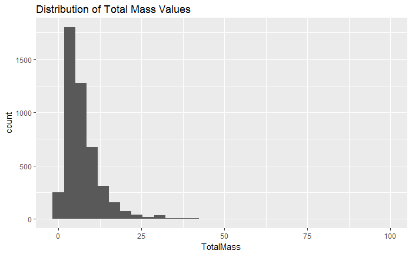

```r
bmdat %>%
  ggplot(aes(x = TotalMass)) +
  geom_histogram() +
  ggtitle("Distribution of Total Mass Values")
```

[output not shown]

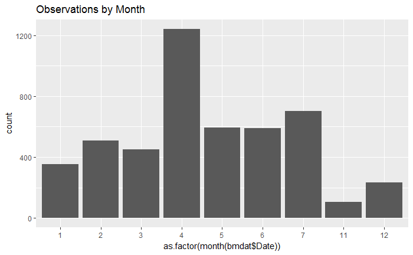

```r
bmdat %>%
  ggplot(aes(x = as.factor(month(bmdat$Date)))) +
  geom_histogram(stat = "count") +
  ggtitle("Observations by Month")
```

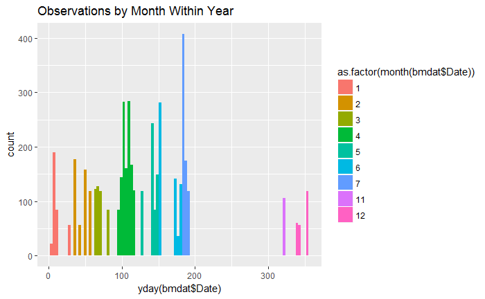

```r
bmdat %>%
  ggplot(aes(x = yday(bmdat$Date),
             fill = as.factor(month(bmdat$Date)))) +
  geom_histogram(bins = 100) +
  ggtitle("Observations by Month Within Year")
```

```
Ignoring unknown parameters: binwidth, bins, pad
```

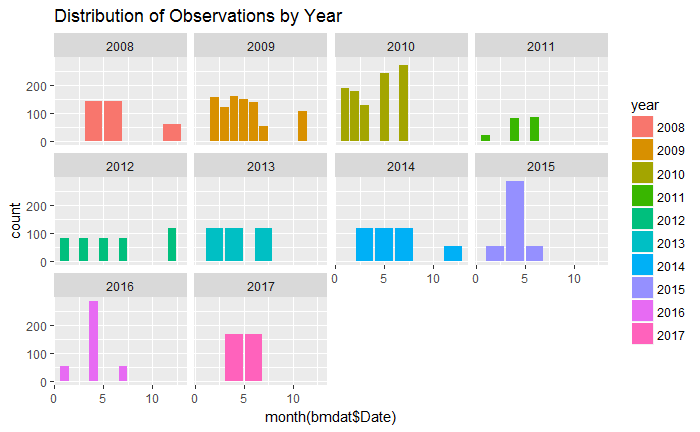

```r
bmdat$year = as.factor(year(bmdat$Date))
bmdat %>%
  ggplot(aes(x = month(bmdat$Date),
             fill = year)) +
  geom_histogram(stat = "count", bins = 12) +
  facet_wrap(~year) +
  ggtitle("Distribution of Observations by Year")
```

# How do biomass values change over time?

Generally see an increasing trend, as expected. Data seems quite right-skewed? May need to just focus on the mid-season range for the most comparable estimates.

```r
# Correcting to make sure total mass values are always present
correct_total <- function(x){

  if(is.na(x$TotalMass) | x$TotalMass == 0){
    if(!is.na(x$SortedLive) | !is.na(x$SortedLitter)){
      x$TotalMass = sum(na.omit(x$SortedLive, x$SortedLitter))
    }
  }

  return(x)
}
bmdat = bmdat %>% do(correct_total(.))
```

```
the condition has length > 1 and only the first element will be used
```

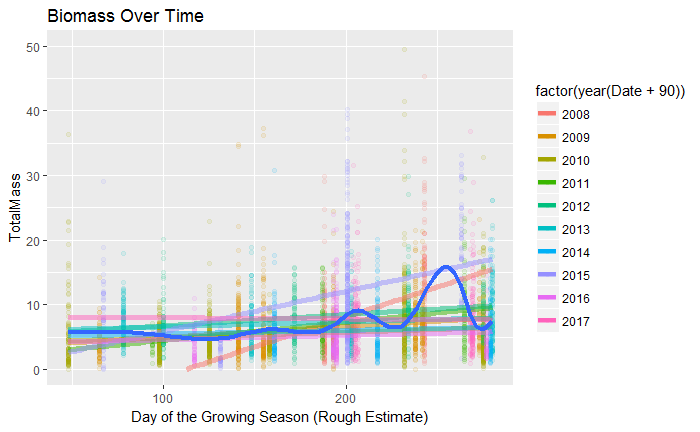

```r
bmdat %>% ggplot(aes(x = yday(Date + 90),
                     y = TotalMass,
                     fill = factor(year(Date + 90)),
                     color = factor(year(Date + 90)))) +
  geom_point(shape = 21, alpha = .1) +
  geom_line(method = "lm", stat = "smooth", size = 2, alpha = .5, fullrange = TRUE) +
  stat_smooth(aes(fill = NULL, color = NULL), se = FALSE, size = 1.5) +
  ylim(0, 50) +
  xlab("Day of the Growing Season (Rough Estimate)") +
  ggtitle("Biomass Over Time")
```

[figure not shown]

# Characterizing Resin Data

As Valerie suggested, resin data was collected in a far more replicated fashion early in the experiment. To use resin data in analysis, it will likely be best to either focus on stability of initial plot compositions and their relationship to resource use, or only track resource use among plots that have consistent coverage through time.

```r
paste("Number of rows without balanced-corrected NO3 observations:",
      sum(is.na(resdat$bcno3)), " (",
      round(sum(is.na(resdat$bcno3))/nrow(resdat),4) * 100, "%)", sep = "")
```

```
[1] "Number of rows without balanced-corrected NO3 observations:1756 (31.82%)"
```

What to do about data that is not blank-corrected?

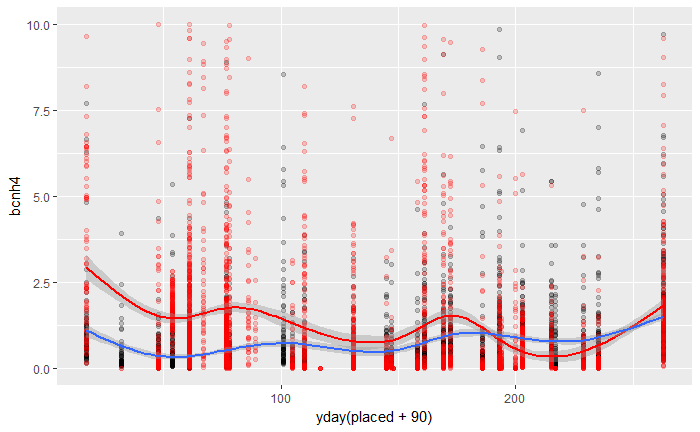